# Checking the Kaggle Stroke Data

AGB

## IPD Check outputs

This is a document outputting all the results from the R code applying the IPD checks. These results are to be interpreted in line with the guidance documents and determination of the checks is to be recorded in the ‘x’ file.

Jump to Domain 2 - Inspecting sequences  
Jump to Check 12  
Jump to Check 13  
Jump to Check 14  
Jump to Check 15  
Jump to Check 16  
Jump to Check 17  
Jump to Check 18  
Jump to Check 19

Jump to Domain 3 - Inspecting relationships between variables  
Jump to Check 20  
Jump to Check 21  
Jump to Check 22  
Jump to Check 23  
Jump to Check 24  
Jump to Check 25  
Jump to Check 26  
Jump to Check 27  
Jump to Check 28  
Jump to Check 29  
Jump to Check 30

Jump to Domain 4 - Inspecting digit/variable distribution  
Jump to Check 31  
Jump to Check 32  
Jump to Check 33  
Jump to Check 34  
Jump to Check 35  
Jump to Check 36  
Jump to Check 37  
Jump to Check 38  
Jump to Check 39  
Jump to Check 40  
Jump to Check 41  
Jump to Check 42  
Jump to Check 43  
Jump to Check 44  
Jump to Check 45  
Jump to Check 46  
Jump to Check 47

Jump to Domain 5 - Inspecting internal/external consistency  
Jump to Check 49  
Jump to Check 51  
Jump to Check 52  
Jump to Check 53  
Jump to Check 57  
Jump to Check 58  
Jump to Check 59

Jump to Domain 6 - Inspecting timings in the dataset  
Jump to Check 60  
Jump to Check 61  
Jump to Check 62  
Jump to Check 63

Jump to Domain 7 - Inspecting the baseline data  
Jump to Check 65  
Jump to Check 66  
Jump to Check 67  
Jump to Check 68

# Domain 2 - Inspecting sequences

### Check 12 - Does plotting variable values in order provided by author, and by study group, reveal any repetition, patterns or differences in patterns between groups?

#### Continuous variables:

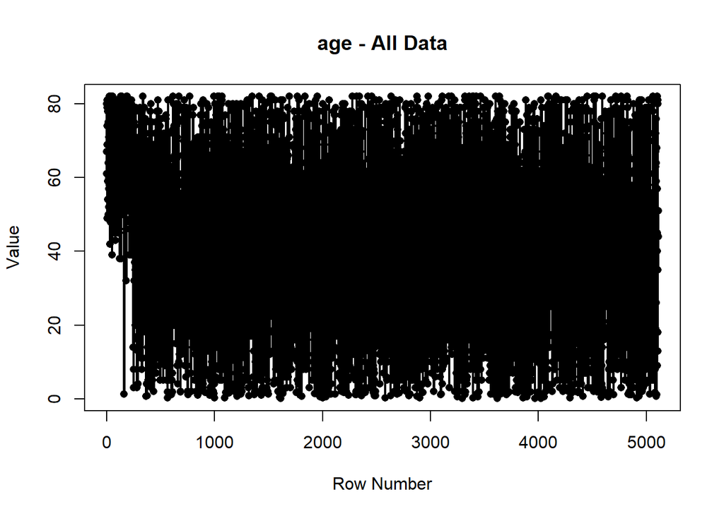

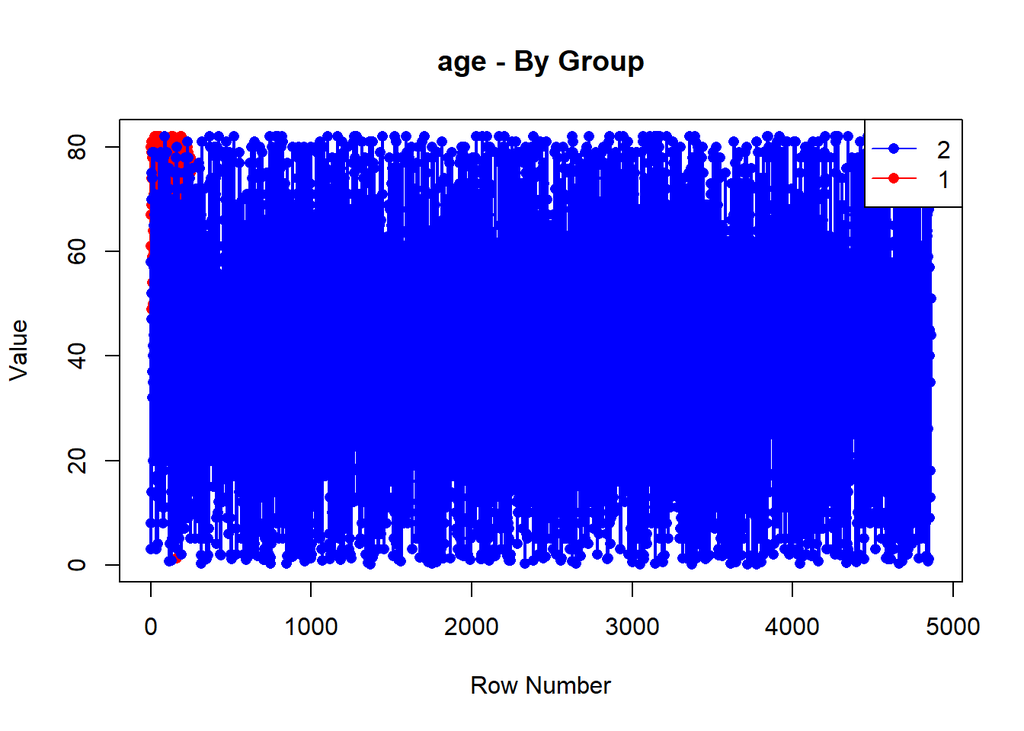

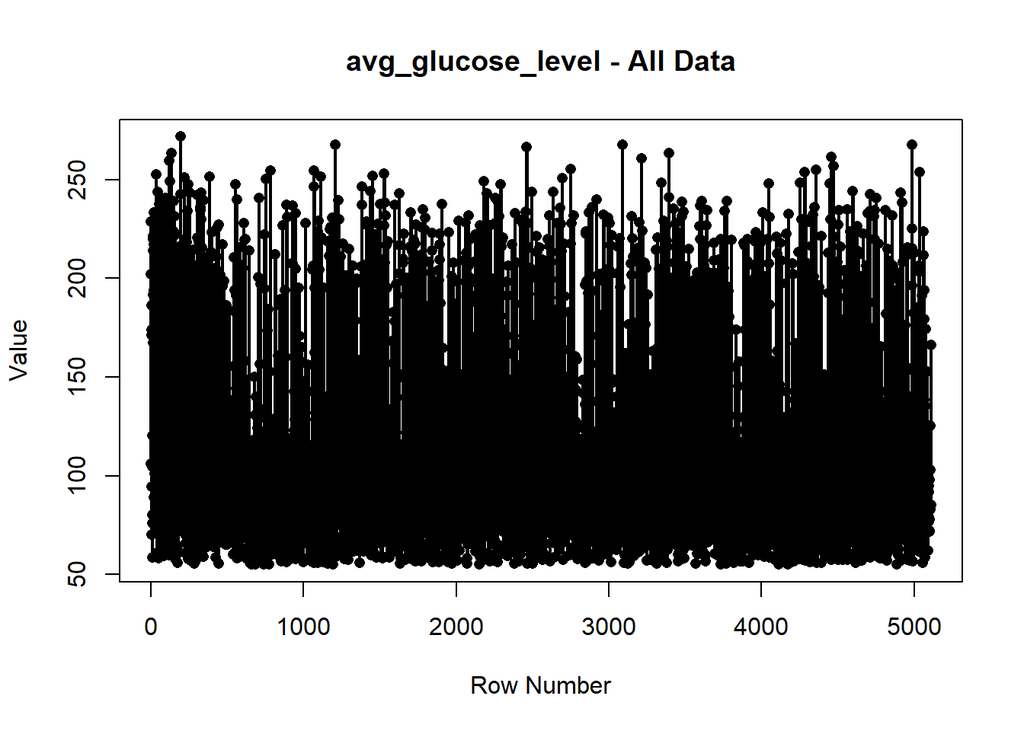

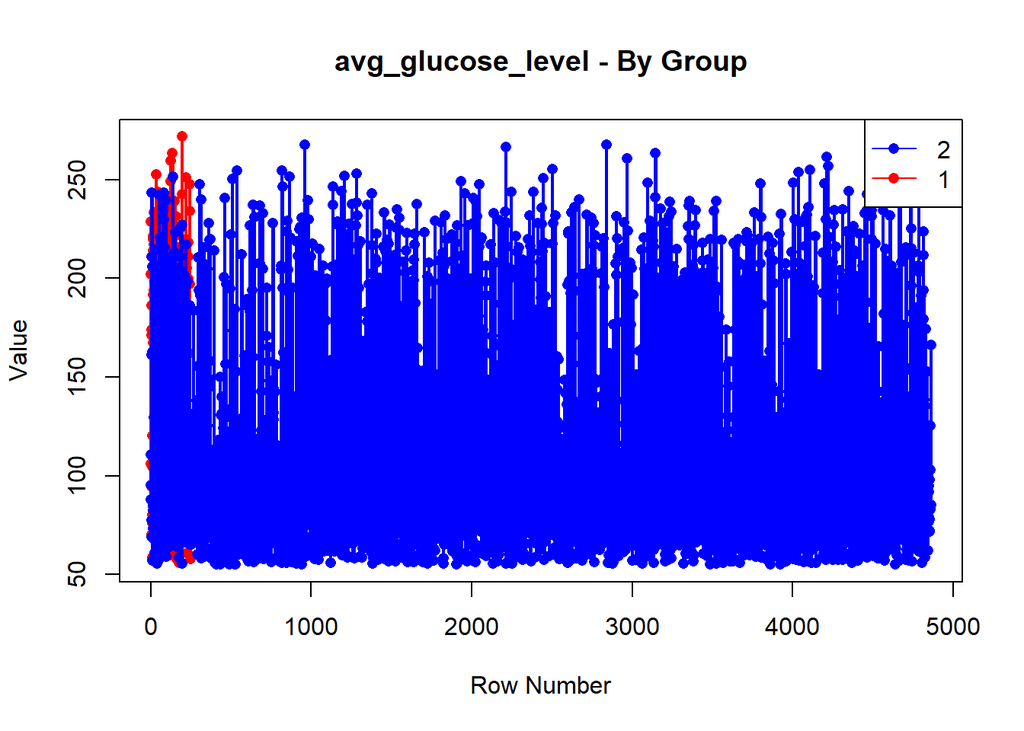

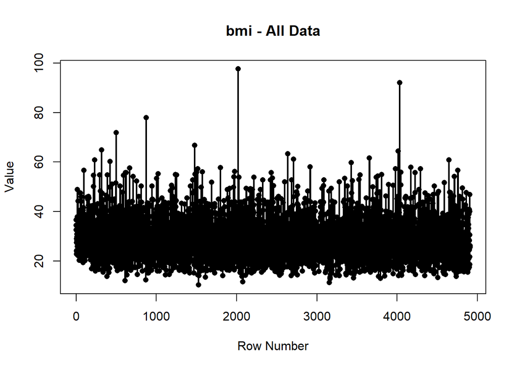

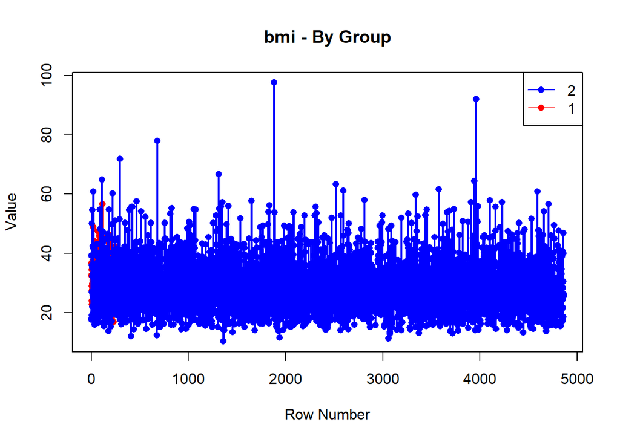

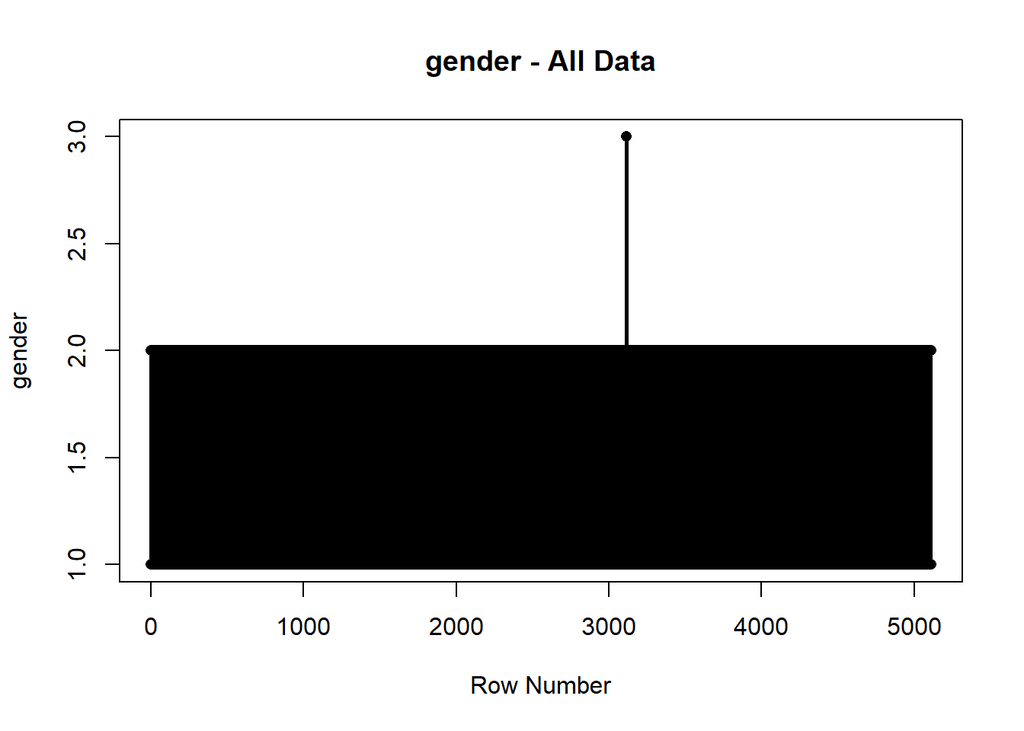

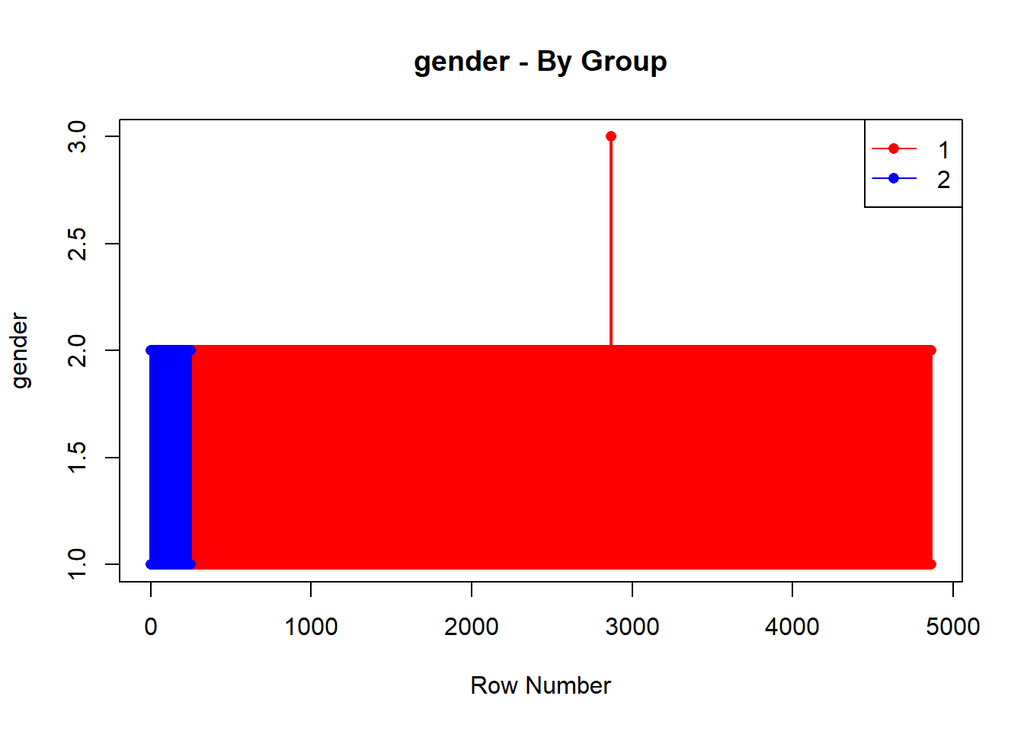

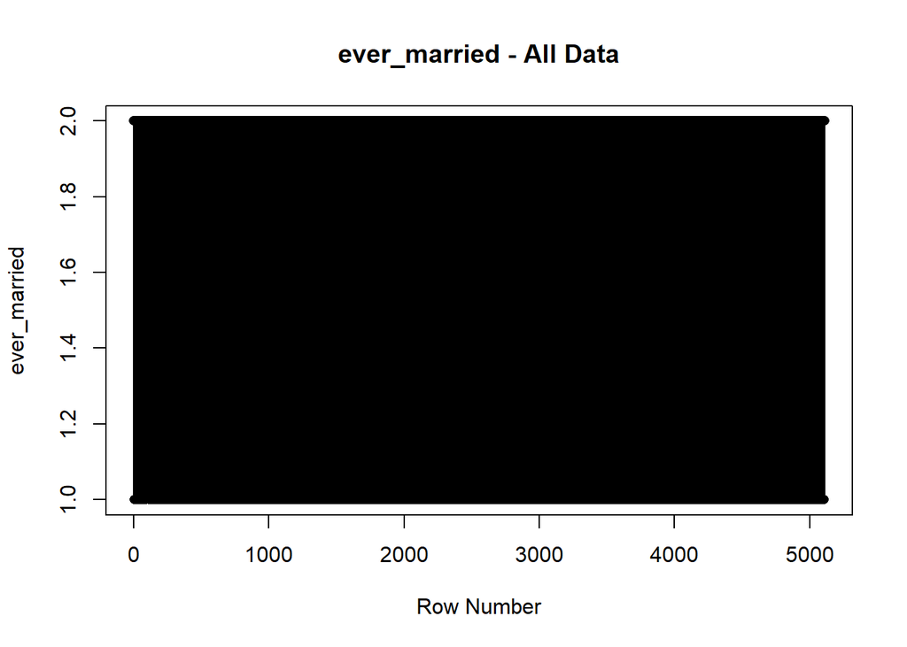

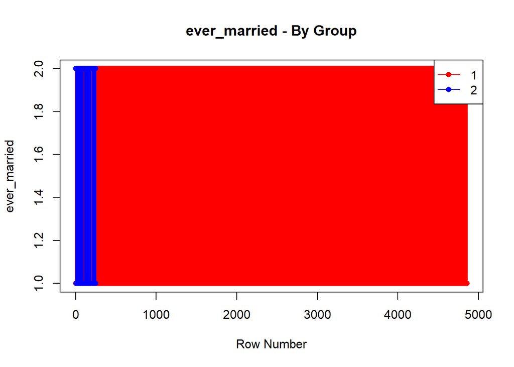

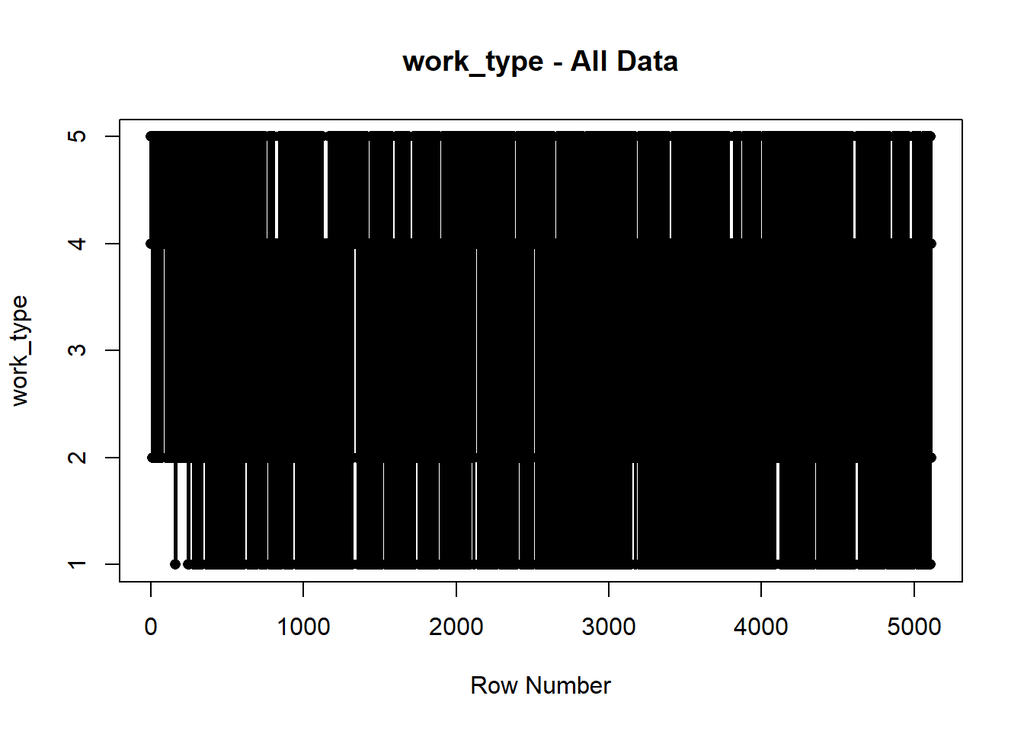

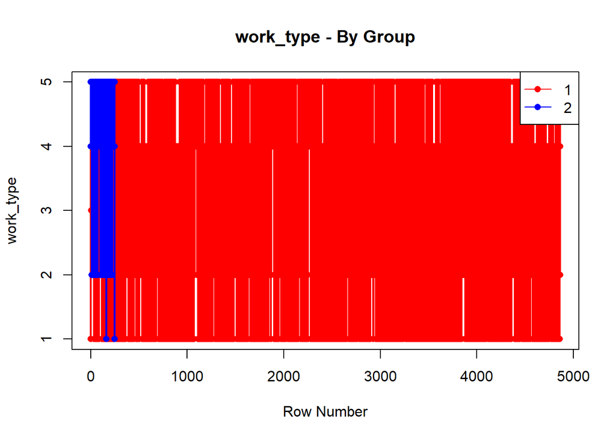

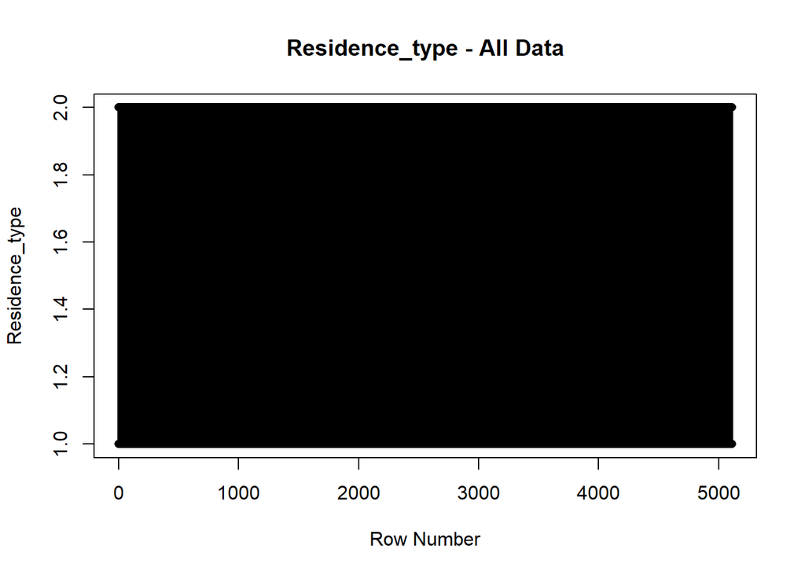

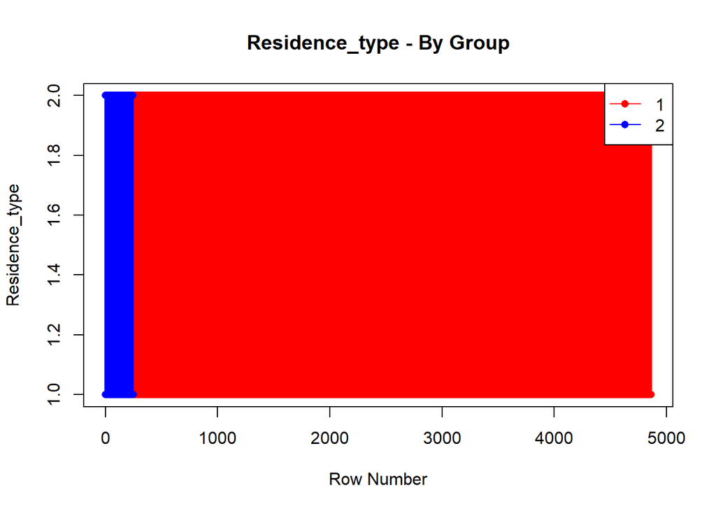

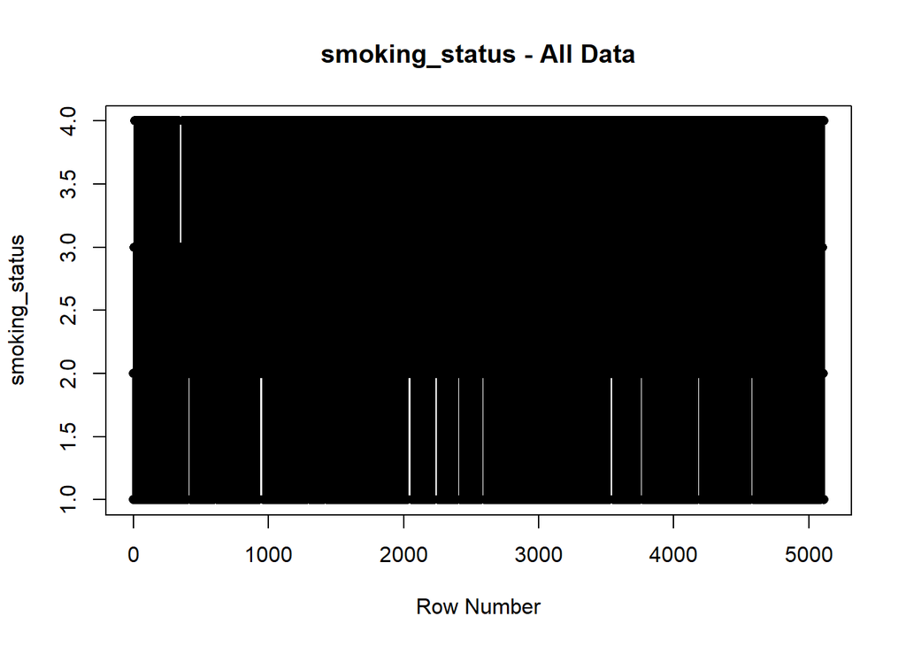

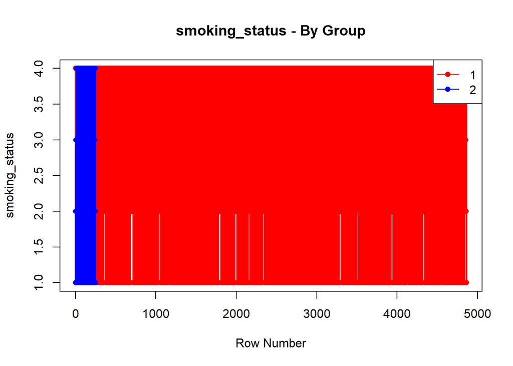

### Check 13 - Does plotting differences between consecutive values within a variable in order provided by author and by group reveal any repetition, patterns or differences in patterns between groups?

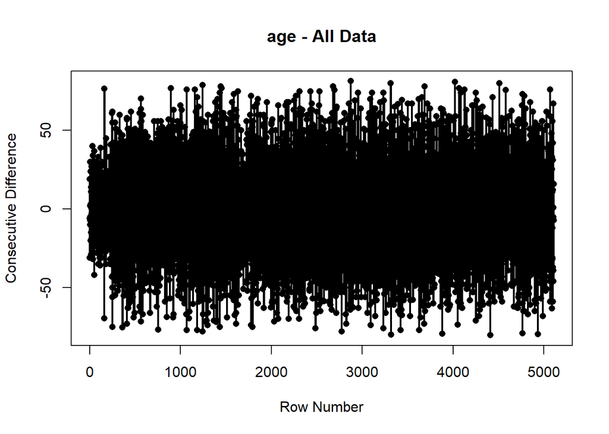

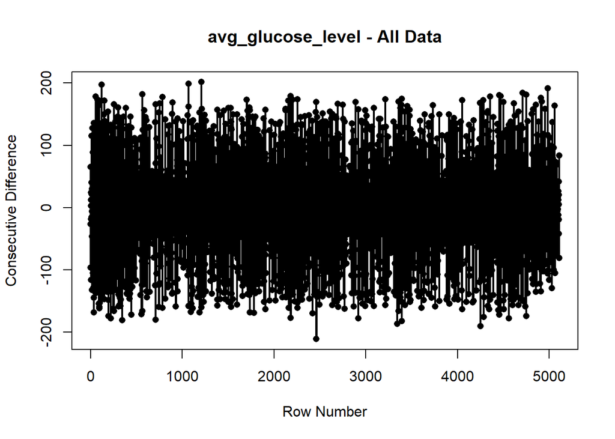

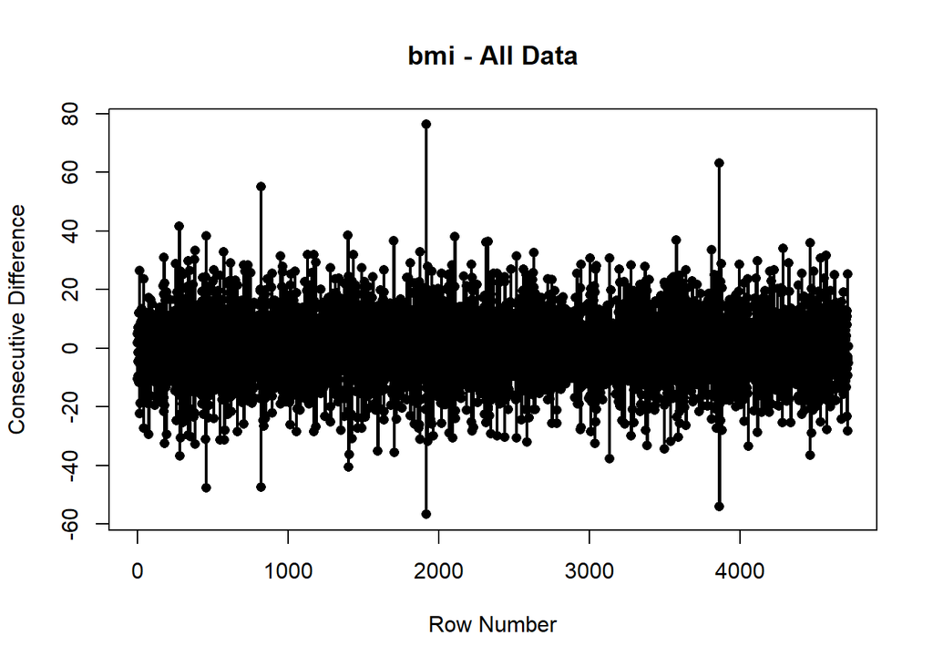

#### Repeating by group

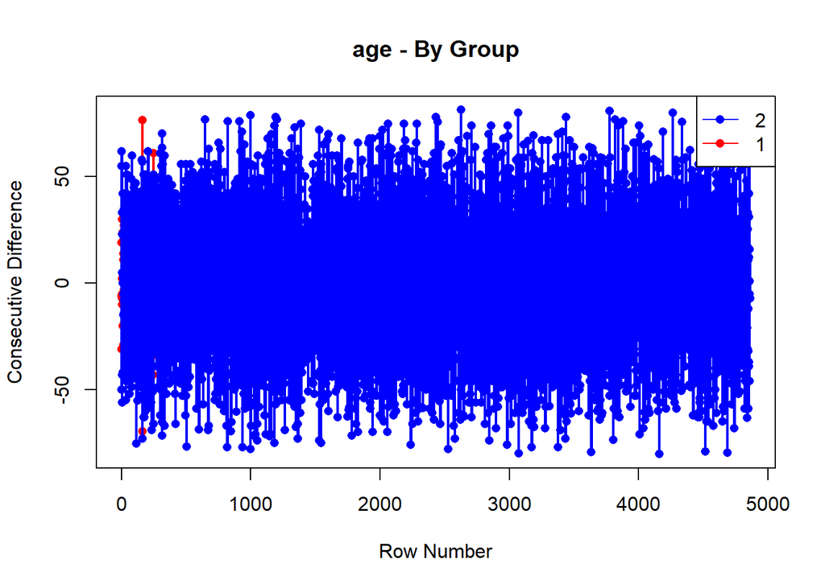

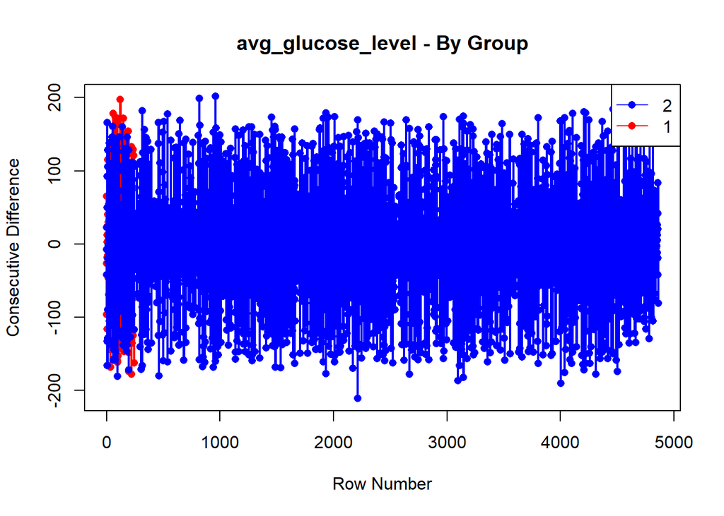

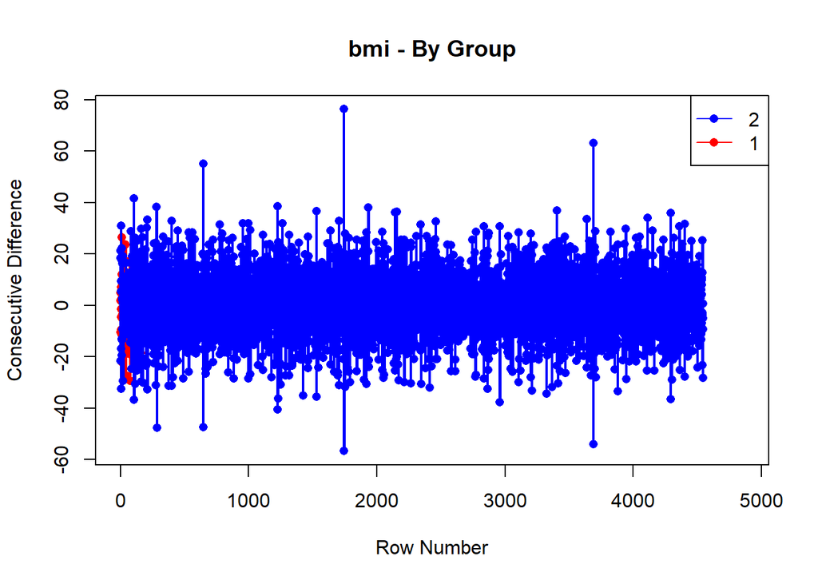

### Check 14 - Does estimating the probability of column sequences via simulation and resampling reveal irregularities?

[output not shown]

**Interpreting bootstrap resampling results:**

**What this test does:**  
This test checks whether the **sum of pairwise differences** between groups (participant 1 in Group 1 vs participant 1 in Group 2, participant 2 vs 2, etc.) is unusually small, which would suggest the data were generated in a coordinated way rather than independently randomized.

**The statistics:** - **Observed Sum of Differences:** Total of |Group1[i] - Group2[i]| across all participants  
- **P-value:** Probability that resampling would produce a sum this small or smaller by chance

**Expected in genuine randomization:**  
- ✅ P-values distributed roughly uniformly (some high, some low)  
- ✅ Most p-values > 0.05  
- ✅ Position in sequence shouldn’t matter for group assignment

**Red flags for fabrication:** - ⚠️ **P < 0.05 for multiple variables:** Sum of differences is suspiciously small - ⚠️ **P < 0.01:** Highly suspicious - values at corresponding positions are more similar than chance - ⚠️ **Multiple variables flagged:** Systematic pattern across dataset

**Why this matters for fabrication detection:**

If a fabricator creates data for Group 1 and Group 2 **sequentially in the same spreadsheet row-by-row**, they might: 1. Generate similar values for the same row positions (e.g., row 10 in both groups gets similar ages) 2. Use one group as a template and modify slightly for the other group 3. Copy-paste with minor adjustments, maintaining positional similarity

**This creates unusually small differences at matched positions**, even if the overall distributions look normal.

**Important caveats:**  
- This test assumes **no meaningful relationship** should exist between participants at the same position in each group’s sequence. If the data were entered in some meaningful order (e.g., both groups sorted by enrollment date, and enrollment date relates to the variable), this could create false positives.  
- P-values based on a small number of comparisons (the smaller of the two group n’s) will not be reliable.

### Check 15 - Are tests of runs within a variable(e.g. resampling, Wald-Wolfowitz) suggestive of fabrication?

Runs Test Results for All Variables

| Variable | Type | Group | P_value |
| --- | --- | --- | --- |
| group | Allocation | All | 0.0000 |
| age | Continuous | All | 0.0000 |
| avg_glucose_level | Continuous | All | 0.7796 |
| bmi | Continuous | All | 0.6280 |
| hypertension | Binary | All | 0.3786 |
| heart_disease | Binary | All | 0.0037 |
| hypertension | Categorical | All | 0.0981 |
| heart_disease | Categorical | All | 0.0488 |
| ever_married | Categorical | All | 0.0448 |
| Residence_type | Categorical | All | 0.2120 |
| smoking_status | Categorical | All | 0.1320 |
| hypertension | Categorical | Group 1 | 0.4884 |
| heart_disease | Categorical | Group 1 | 0.6358 |
| ever_married | Categorical | Group 1 | 0.4783 |
| Residence_type | Categorical | Group 1 | 0.1557 |
| smoking_status | Categorical | Group 1 | 0.0991 |
| gender | Categorical | Group 2 | 0.8563 |
| hypertension | Categorical | Group 2 | 0.7882 |
| heart_disease | Categorical | Group 2 | 0.0362 |
| ever_married | Categorical | Group 2 | 0.9803 |
| Residence_type | Categorical | Group 2 | 0.7802 |
| smoking_status | Categorical | Group 2 | 0.7487 |

```
##
##
## **Interpretation:** Low p-values (< 0.05) indicate non-random patterns in the data sequence. This could suggest either excessive alternation (values switching more often than expected by chance) or excessive clustering (long runs of similar values).
```

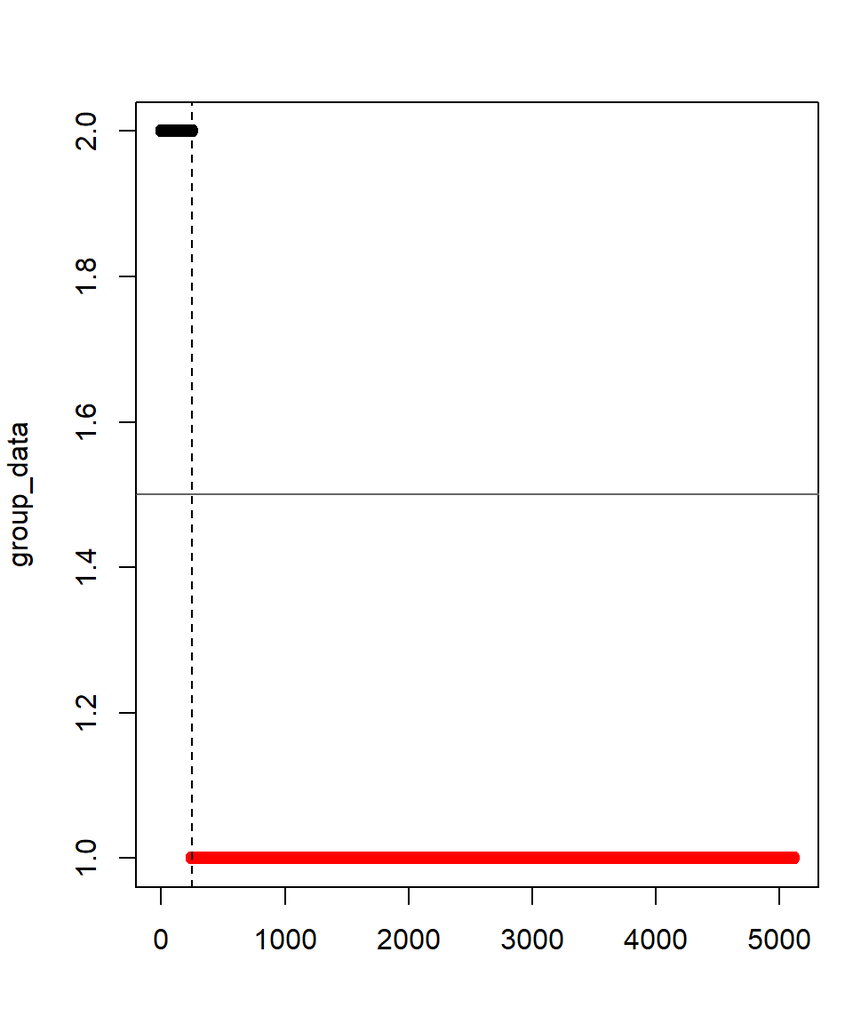

```
##
##  Runs Test
##
## data:  group_data
## statistic = -71.402, runs = 2, n1 = 249, n2 = 4861, n = 5110, p-value <
## 2.2e-16
## alternative hypothesis: nonrandomness
```

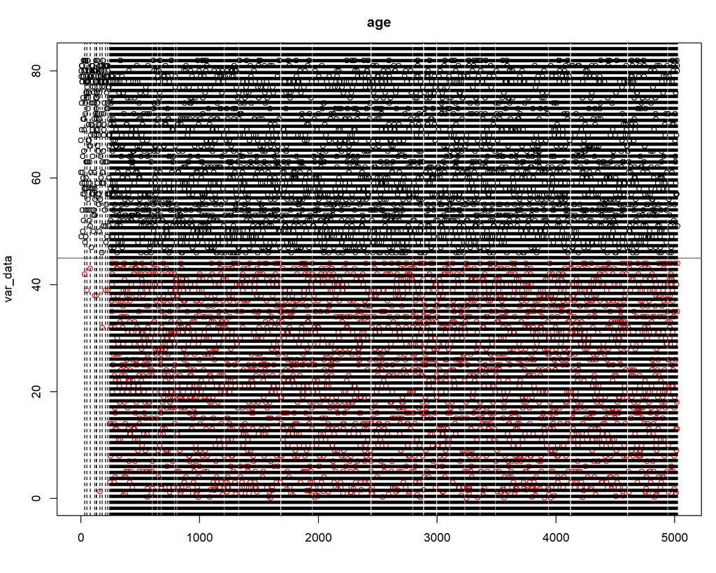

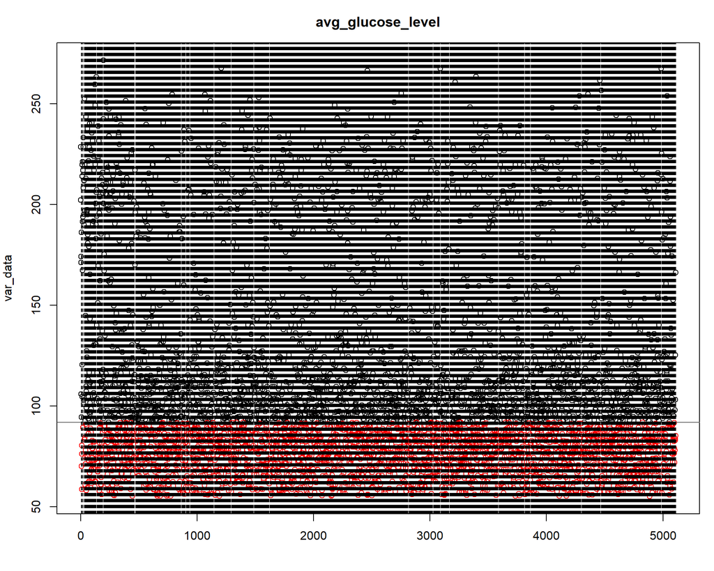

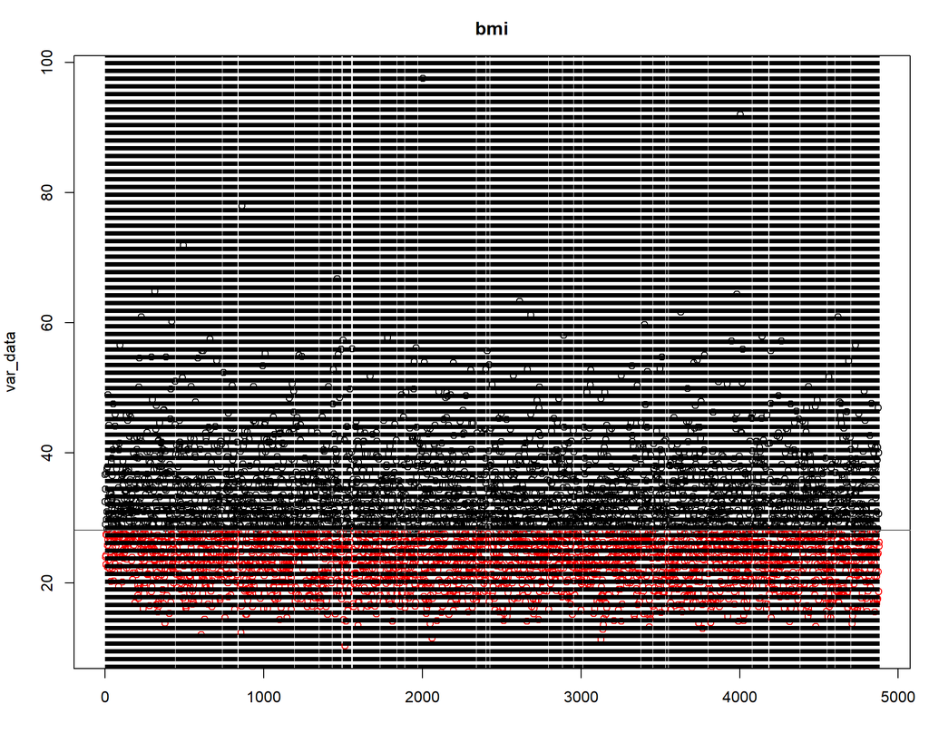

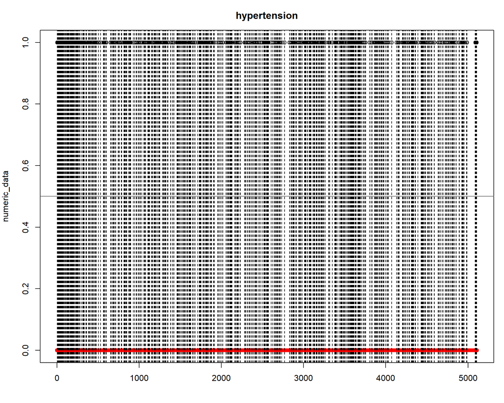

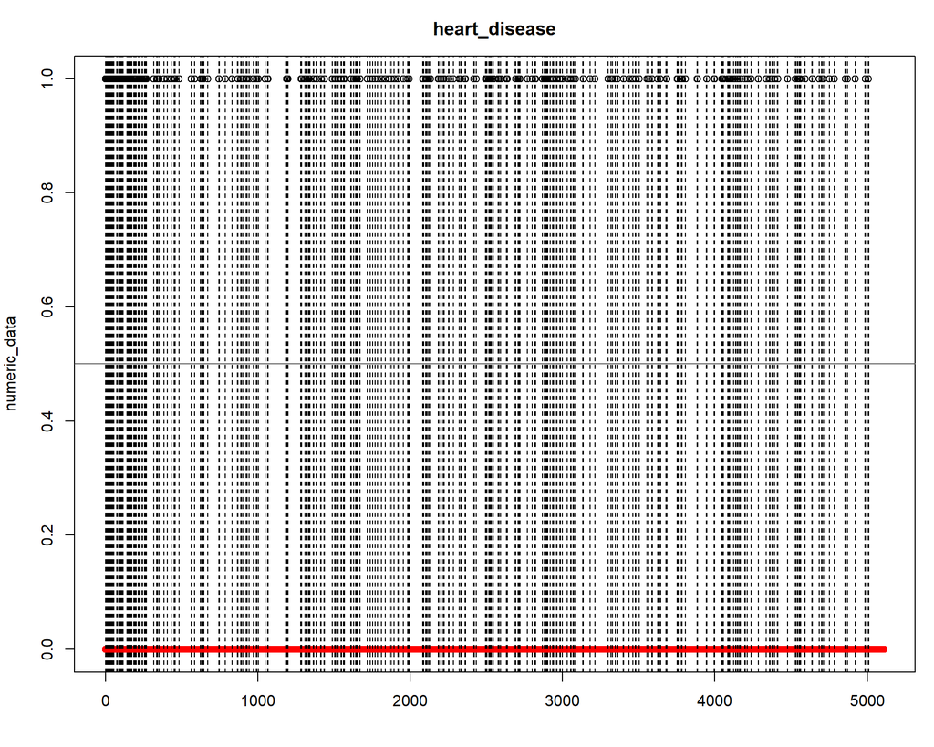

### Check 16 - Are there implausible sequences in decimal places (after deleting integer)?

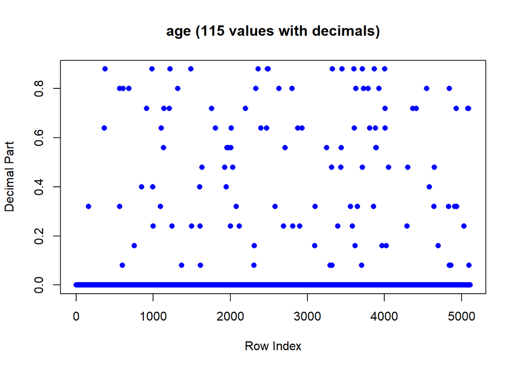

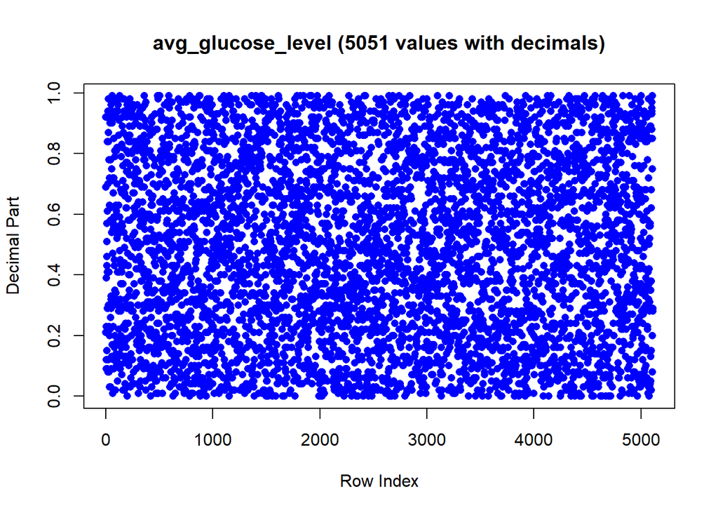

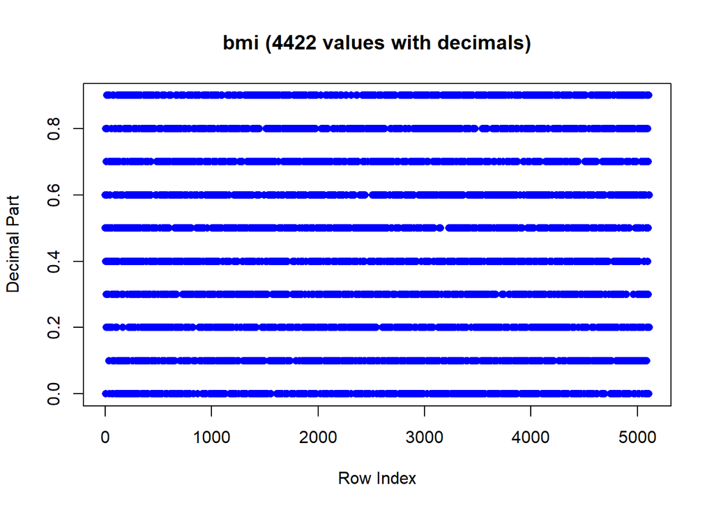

```
##
## 3 variables contained decimal places and were plotted above.
```